# Final Project Proposal

MGSC 310 Final Projet Proposal

Hudson Pak, Justin Lewinski, Everett Prussak

```r
# load all your libraries here
library('tidyverse')
library(ggcorrplot)
library(rsample)
library(plotROC)
library(yardstick)
library(glmnet)
library(glmnetUtils)
library(Metrics)
# note, do not run install.packages() inside a code chunk. install them in the console outside of a code chunk.
```

Summary Statistics

```r
# code
data <- read.csv('diabetes.csv')
#data <- data[-7]
data <- data %>%
  mutate(bp_st = BloodPressure*SkinThickness,
         age_squared = Age * Age,
         glucose_insulin = Glucose * Insulin,
         insulin_squared = Insulin * Insulin,
         Outcome = factor(Outcome)
         )

dim(data)
```

```
## [1] 768  13
```

```r
data <- data %>% filter(
  Glucose > 0,
  BloodPressure > 0,
  SkinThickness > 0,
  BMI > 0
)

head(data)
```

|  | Pregnancies | Glucose | BloodPressure | SkinThickness | Insulin | BMI | DiabetesPedigreeFunction | Age | Outcome | bp_st | age_squared | glucose_insulin | insulin_squared |
| --- | --- | --- | --- | --- | --- | --- | --- | --- | --- | --- | --- | --- | --- |
| 1 | 6 | 148 | 72 | 35 | 0 | 33.6 | 0.627 | 50 | 1 | 2520 | 2500 | 0 | 0 |
| 2 | 1 | 85 | 66 | 29 | 0 | 26.6 | 0.351 | 31 | 0 | 1914 | 961 | 0 | 0 |
| 3 | 1 | 89 | 66 | 23 | 94 | 28.1 | 0.167 | 21 | 0 | 1518 | 441 | 8366 | 8836 |
| 4 | 0 | 137 | 40 | 35 | 168 | 43.1 | 2.288 | 33 | 1 | 1400 | 1089 | 23016 | 28224 |
| 5 | 3 | 78 | 50 | 32 | 88 | 31.0 | 0.248 | 26 | 1 | 1600 | 676 | 6864 | 7744 |
| 6 | 2 | 197 | 70 | 45 | 543 | 30.5 | 0.158 | 53 | 1 | 3150 | 2809 | 106971 | 294849 |

```r
summary(data)
```

```
##   Pregnancies        Glucose       BloodPressure    SkinThickness
##  Min.   : 0.000   Min.   : 56.00   Min.   : 24.00   Min.   : 7.00
##  1st Qu.: 1.000   1st Qu.: 98.75   1st Qu.: 64.00   1st Qu.:22.00
##  Median : 2.000   Median :115.00   Median : 72.00   Median :29.00
##  Mean   : 3.517   Mean   :121.03   Mean   : 71.51   Mean   :29.18
##  3rd Qu.: 5.000   3rd Qu.:141.25   3rd Qu.: 80.00   3rd Qu.:36.00
##  Max.   :17.000   Max.   :199.00   Max.   :110.00   Max.   :99.00
##     Insulin           BMI        DiabetesPedigreeFunction
##  Min.   :  0.0   Min.   :18.20   Min.   :0.0850
##  1st Qu.:  0.0   1st Qu.:27.88   1st Qu.:0.2587
##  Median : 91.5   Median :32.80   Median :0.4160
##  Mean   :115.0   Mean   :32.89   Mean   :0.5030
##  3rd Qu.:165.2   3rd Qu.:36.90   3rd Qu.:0.6585
##  Max.   :846.0   Max.   :67.10   Max.   :2.4200
##       Age        Outcome     bp_st       age_squared
##  Min.   :21.00   0:355   Min.   : 434   Min.   : 441
##  1st Qu.:23.00   1:177   1st Qu.:1423   1st Qu.: 529
##  Median :28.00           Median :2040   Median : 784
##  Mean   :31.61           Mean   :2116   Mean   :1115
##  3rd Qu.:38.00           3rd Qu.:2660   3rd Qu.:1444
##  Max.   :81.00           Max.   :6930   Max.   :6561
##  glucose_insulin  insulin_squared
##  Min.   :     0   Min.   :     0
##  1st Qu.:     0   1st Qu.:     0
##  Median :  9460   Median :  8372
##  Mean   : 15667   Mean   : 28325
##  3rd Qu.: 20878   3rd Qu.: 27308
##  Max.   :159894   Max.   :715716
```

```r
dim(data)
```

```
## [1] 532  13
```

age_squared and bp_st are created because the original model was slightly underfit. By adding these created variables, the model became mode complex and allowed for the model to be less underfit.

Train-Test-Split

```r
# code
library(rsample)
set.seed(300)
data_split <- initial_split(data,prop=0.8)
data_train <- training(data_split)
data_test <- testing(data_split)
```

Logistic Regression Model

```r
logit <- glm(Outcome ~ .,
             data = data_train,
             family = binomial
             )

summary(logit)
```

```
##
## Call:
## glm(formula = Outcome ~ ., family = binomial, data = data_train)
##
## Deviance Residuals:
##     Min       1Q   Median       3Q      Max
## -2.4286  -0.6241  -0.3209   0.6423   2.4824
##
## Coefficients:
##                               Estimate    Std. Error z value
## (Intercept)              -16.907925470   3.381907708  -5.000
## Pregnancies                0.020220881   0.051499244   0.393
## Glucose                    0.047049406   0.008009346   5.874
## BloodPressure              0.004902346   0.040021767   0.122
## SkinThickness              0.054824629   0.084722648   0.647
## Insulin                    0.005867274   0.005316311   1.104
## BMI                        0.087597413   0.026116285   3.354
## DiabetesPedigreeFunction   1.185424729   0.406757352   2.914
## Age                        0.343362627   0.092321849   3.719
## bp_st                     -0.000851022   0.001139141  -0.747
## age_squared               -0.003807216   0.001133200  -3.360
## glucose_insulin           -0.000057023   0.000043480  -1.312
## insulin_squared            0.000002217   0.000005092   0.435
##                               Pr(>|z|)
## (Intercept)              0.00000057472 ***
## Pregnancies                   0.694582
## Glucose                  0.00000000425 ***
## BloodPressure                 0.902509
## SkinThickness                 0.517563
## Insulin                       0.269751
## BMI                           0.000796 ***
## DiabetesPedigreeFunction      0.003565 **
## Age                           0.000200 ***
## bp_st                         0.455019
## age_squared                   0.000780 ***
## glucose_insulin               0.189689
## insulin_squared               0.663294
## ---
## Signif. codes:  0 '***' 0.001 '**' 0.01 '*' 0.05 '.' 0.1 ' ' 1
##
## (Dispersion parameter for binomial family taken to be 1)
##
##     Null deviance: 548.13  on 424  degrees of freedom
## Residual deviance: 360.23  on 412  degrees of freedom
## AIC: 386.23
##
## Number of Fisher Scoring iterations: 5
```

Exponentiating Coefficients

```r
exp(logit$coefficients)
```

```
##              (Intercept)              Pregnancies
##          0.0000000453922          1.0204267083219
##                  Glucose            BloodPressure
##          1.0481737939750          1.0049143825151
##            SkinThickness                  Insulin
##          1.0563553446316          1.0058845199720
##                      BMI DiabetesPedigreeFunction
##          1.0915485901731          3.2720762732297
##                      Age                    bp_st
##          1.4096798574657          0.9991493397911
##              age_squared          glucose_insulin
##          0.9962000223721          0.9999429782156
##          insulin_squared
##          1.0000022168939
```

Scoring the model:

```r
results_train <- data.frame(
  true_numeric = as.numeric(data_train$Outcome),
  true_factor = data_train$Outcome,
  scores = predict(logit, type = 'response', newdata = data_train)
)

results_test <- data.frame(
  true_numeric = as.numeric(data_test$Outcome),
  true_factor = data_test$Outcome,
  scores = predict(logit, type = 'response', newdata = data_test)
)
```

ROC Curves:

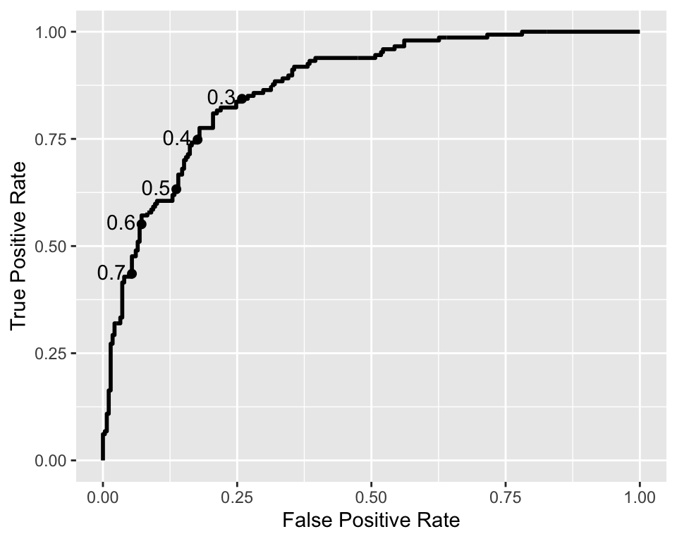

```r
roc_train <- ggplot(results_train, aes(m=scores, d=true_numeric)) +
  geom_roc(cutoffs.at = c(0.7,0.6,0.5,0.4,0.3)) +
  labs("ROC Curve (Train)", x = "False Positive Rate", y ="True Positive Rate")

print(roc_train)
```

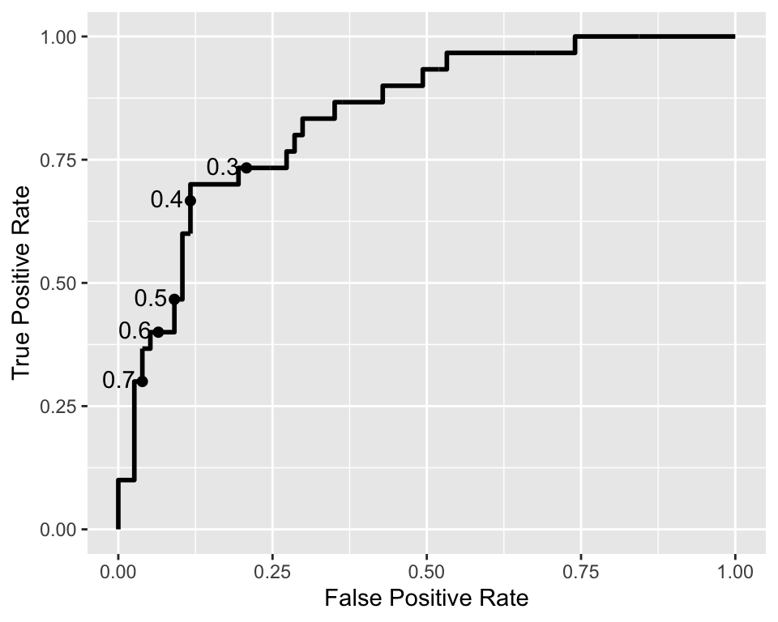

```r
roc_test <- ggplot(results_test, aes(m=scores, d=true_numeric)) +
  geom_roc(cutoffs.at = c(0.7,0.6,0.5,0.4,0.3)) +
  labs("ROC Curve (Test)", x = "False Positive Rate", y ="True Positive Rate")

print(roc_test)
```

From these two graph’s, we chose a cutoff value of 0.3 because it seems to be a good cutoff as it results in balanced false and true positive rates.

Class Assignments

```r
predicted_train <- ifelse(results_train$scores>0.3,1,0)
results_train <- results_train %>%
  mutate(predicted = factor(predicted_train))

results_train %>% glimpse()
```

[output not shown]

```r
predicted_test <- ifelse(results_test$scores>0.3,1,0)
results_test <- results_test %>%
  mutate(predicted = factor(predicted_test))

results_test %>% glimpse()
```

[output not shown]

Train Confusion Matrix

```r
train_cm <- conf_mat(results_train, truth = true_factor, estimate = predicted)
print(train_cm)
```

[output not shown]

Train Accuracy, Sensitivity, and Specificity Scores:

```r
accuracy <- (207+124) / (207+124+23+71)
paste0('Accuracy for the train is ', round(accuracy,4)*100, ' percent')
```

```
## [1] "Accuracy for the train is 77.88 percent"
```

```r
sensitivity <- (124) / (124 + 23)
paste0('Sensitivity for the train is ', round(sensitivity,4)*100, ' percent')
```

```
## [1] "Sensitivity for the train is 84.35 percent"
```

```r
specificity <- (207) / (207 + 71)
paste0('Specificity for the train is ', round(specificity,4)*100, ' percent')
```

```
## [1] "Specificity for the train is 74.46 percent"
```

Test Confusion Matrix

```r
cm_test <- conf_mat(results_test, truth = true_factor, estimate = predicted)
print(cm_test)
```

[output not shown]

Test Accuracy, Sensitivity, and Specificity Scores:

```r
accuracy <- (62+22) / (22+62+8+15)
paste0('Accuracy for the test is ', round(accuracy,4)*100, ' percent')
```

```
## [1] "Accuracy for the test is 78.5 percent"
```

```r
sensitivity <- (22) / (22+8)
paste0('Sensitivity for the test is ', round(sensitivity,4)*100, ' percent')
```

```
## [1] "Sensitivity for the test is 73.33 percent"
```

```r
specificity <- (62) / (62 + 15)
paste0('Specificity for the test is ', round(specificity,4)*100, ' percent')
```

```
## [1] "Specificity for the test is 80.52 percent"
```

AUC

```r
calc_auc(roc_train)
```

|  | PANEL | group | AUC |
| --- | --- | --- | --- |
| 1 | 1 | -1 | 0.8711398 |

```r
calc_auc(roc_test)
```

|  | PANEL | group | AUC |
| --- | --- | --- | --- |
| 1 | 1 | -1 | 0.838961 |

The AUC for the training data is 0.87 and AUC for the testing data is 0.84. These numbers are close to each, but can show a slight overfitting.

Decision Tree Model

```r
library(tree)
tree_diabetes <- tree(Outcome ~.,
                 data = data_train)
              #   control = tree.control(nobs=nrow(data_train),
                      #                  mindev = 0.005))

summary(tree_diabetes)
```

```
##
## Classification tree:
## tree(formula = Outcome ~ ., data = data_train)
## Variables actually used in tree construction:
## [1] "Glucose"                  "Age"
## [3] "SkinThickness"            "DiabetesPedigreeFunction"
## [5] "BloodPressure"            "BMI"
## [7] "bp_st"                    "Pregnancies"
## Number of terminal nodes:  22
## Residual mean deviance:  0.6235 = 251.3 / 403
## Misclassification error rate: 0.1365 = 58 / 425
```

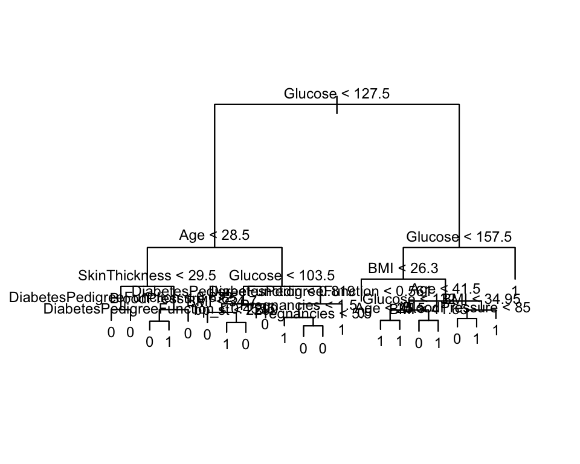

```r
plot(tree_diabetes)
text(tree_diabetes,pretty=0, cex = 0.75)
```

Pruning Tree

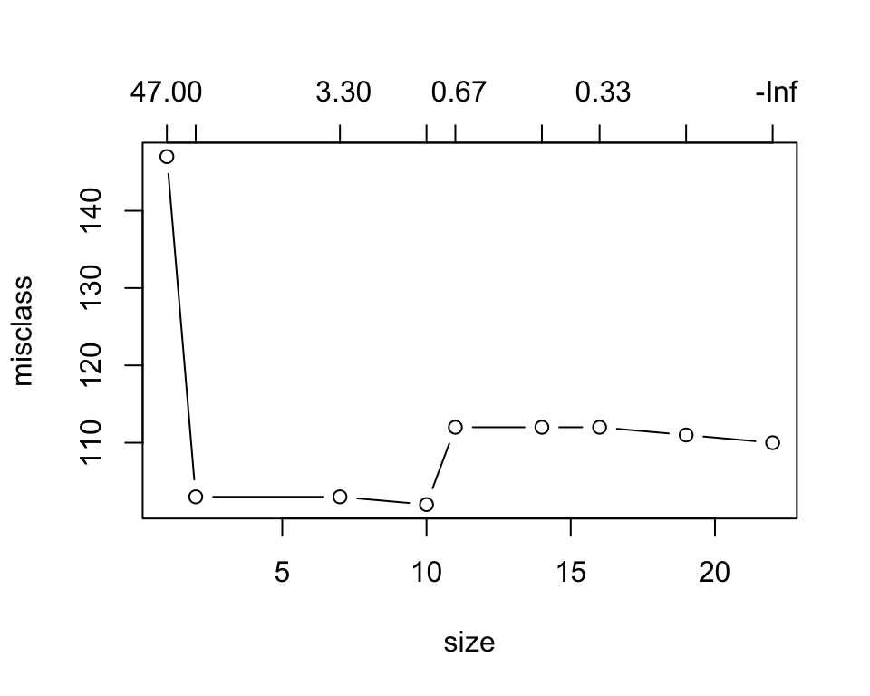

```r
cv.diabetes <- cv.tree(tree_diabetes, FUN=prune.misclass)

plot(cv.diabetes, type='b')
```

```r
cv_results <- data.frame(
  tree_size = cv.diabetes$size,
  error = cv.diabetes$dev
)

print(cv_results)
```

```
##   tree_size error
## 1        22   110
## 2        19   111
## 3        16   112
## 4        14   112
## 5        11   112
## 6        10   102
## 7         7   103
## 8         2   103
## 9         1   147
```

```r
pruned_tree <- prune.tree(tree_diabetes, best = 10)
```

Pruned Tree Plot

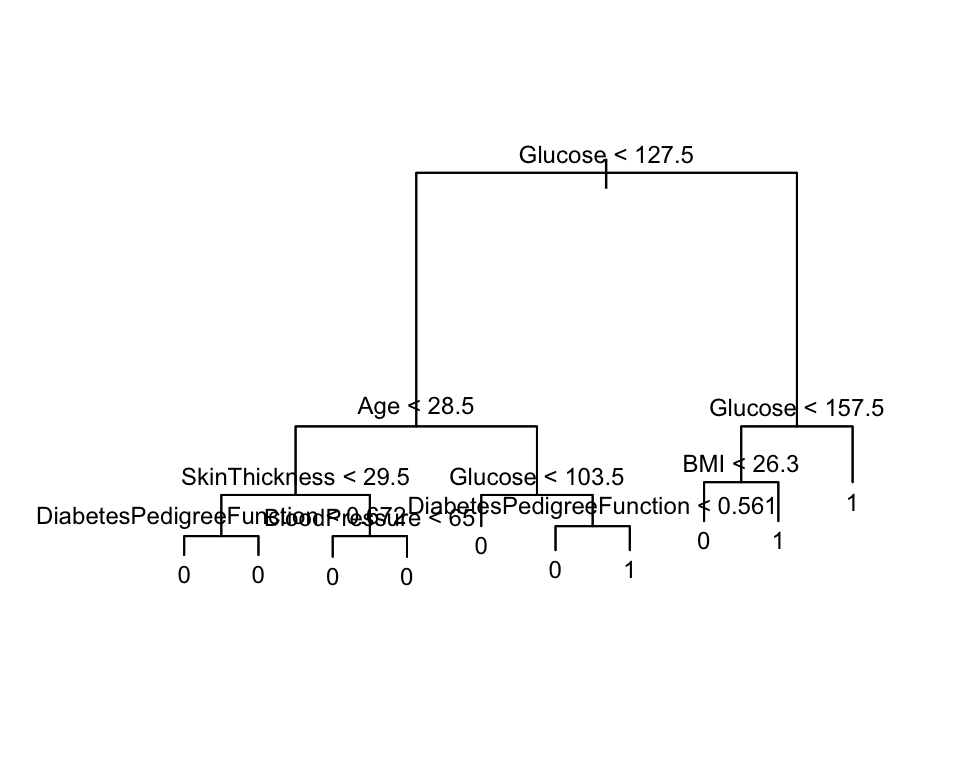

```r
# plot the pruned tree
plot(pruned_tree)
text(pruned_tree, pretty=0, cex = 0.75)
```

Train Results

```r
results_train_2 <- data.frame(
  true_numeric = as.numeric(data_train$Outcome),
  true_factor = data_train$Outcome,
  predict = predict(pruned_tree, type = 'class', newdata = data_train)
)

library(yardstick)
cm_train_2 <- conf_mat(results_train_2, truth = true_factor, estimate = predict)
print(cm_train_2)
```

```
##           Truth
## Prediction   0   1
##          0 230  32
##          1  48 115
```

```r
accuracy <- (230+115) / (230+115+48+32)
paste0('Accuracy for the test is ', round(accuracy,4)*100, ' percent')
```

```
## [1] "Accuracy for the test is 81.18 percent"
```

```r
sensitivity <- (115) / (115+32)
paste0('Sensitivity for the test is ', round(sensitivity,4)*100, ' percent')
```

```
## [1] "Sensitivity for the test is 78.23 percent"
```

```r
specificity <- (230) / (230+48)
paste0('Specificity for the test is ', round(specificity,4)*100, ' percent')
```

```
## [1] "Specificity for the test is 82.73 percent"
```

Test Results

```r
results_test_2 <- data.frame(
  true_numeric = as.numeric(data_test$Outcome),
  true_factor = data_test$Outcome,
  predict = predict(pruned_tree, type = 'class', newdata = data_test)
)

library(yardstick)
cm_test_2 <- conf_mat(results_test_2, truth = true_factor, estimate = predict)
print(cm_test_2)
```

```
##           Truth
## Prediction  0  1
##          0 60 10
##          1 17 20
```

```r
accuracy <- (60+20) / (20+60+17+10)
paste0('Accuracy for the test is ', round(accuracy,4)*100, ' percent')
```

```
## [1] "Accuracy for the test is 74.77 percent"
```

```r
sensitivity <- (20) / (20+10)
paste0('Sensitivity for the test is ', round(sensitivity,4)*100, ' percent')
```

```
## [1] "Sensitivity for the test is 66.67 percent"
```

```r
specificity <- (60) / (60 + 17)
paste0('Specificity for the test is ', round(specificity,4)*100, ' percent')
```

```
## [1] "Specificity for the test is 77.92 percent"
```

AUC Scores

```r
library(pROC)

train_auc <- roc(results_train_2$true_numeric, as.numeric(results_train_2$predict))
print("Train AUC")
```

```
## [1] "Train AUC"
```

```r
print(train_auc)
```

```
##
## Call:
## roc.default(response = results_train_2$true_numeric, predictor = as.numeric(results_train_2$predict))
##
## Data: as.numeric(results_train_2$predict) in 278 controls (results_train_2$true_numeric 1) < 147 cases (results_train_2$true_numeric 2).
## Area under the curve: 0.8048
```

```r
test_auc <- roc(results_test_2$true_numeric, as.numeric(results_test_2$predict))

print("Test AUC")
```

```
## [1] "Test AUC"
```

```r
print(test_auc)
```

```
##
## Call:
## roc.default(response = results_test_2$true_numeric, predictor = as.numeric(results_test_2$predict))
##
## Data: as.numeric(results_test_2$predict) in 77 controls (results_test_2$true_numeric 1) < 30 cases (results_test_2$true_numeric 2).
## Area under the curve: 0.7229
```